# Trabajo en HTML

Mateo López

2023-11-12

# Carga de librerías

```r
library(pacman)
packages = c("MASS","knitr","tidyverse","car",'dplyr','kableExtra',"tidyr","readr","magrittr")
pacman::p_load(char=packages)
```

# Carga de ficheros

Para crear el dataset con el que vamos a tratar en este proyecto, hemos extraido varios archivos de la [web](https://valencia.opendatasoft.com/pages/home/) del portal de datos abiertos del Ayuntamiento de Valencia. En ellos tenemos diferente información acerca de los 88 barrios que hay en Valencia, como pueden ser el número de zonas verdes, precio del alquiler, actividad comercial, renta, etc. Antes de atacar las preguntas que nuestro conjunto resolverá, vamos a cargar los datos y unirlos en un único dataset, con una variable común para todos, el barrio.

## Vulnerabilidad

El primer dataset [Vulnerabilidad](https://valencia.opendatasoft.com/explore/dataset/vulnerabilidad/table/) nos da información general del barrio, como la densidad de población, la renta media, o el estado de vulnerabilidad. Esta última variable será de gran interés en nuestro análisis posterior.

```r
vuln <- read_delim("./data/vulnerabilidad.csv",
    delim = ";", escape_double = FALSE, col_types = cols(`Geo Point` = col_skip(),
        `Geo Shape` = col_skip(), `Densitat_p` = col_skip()),
    trim_ws = TRUE)%>%arrange(nombre)

colnames(vuln)[colnames(vuln) == "nombre"] <-"Barrio"
colnames(vuln)[colnames(vuln) == "Index_Gl_1"] <-"Indice_Vuln"


vuln$Barrio<-factor(vuln$Barrio,levels = unique(vuln$Barrio))
vuln$Indice_Vuln<-factor(vuln$Indice_Vuln,levels = c("Vulnerable","Pot. Vulnerable","No Vulnerable"))

head(vuln)
```

```
# A tibble: 6 × 13
  Barrio      coddistbar coddistrit codbar `Zones verd` turismes_e atur_16_64 renda_mitj risc_pobre
  <fct>       <chr>           <dbl>  <dbl>        <dbl>      <dbl>      <dbl>      <dbl>      <dbl>
1 AIORA       121                12    121         1786       12.2     180.       10228.       24.3
2 ALBORS      122                12    122          712       12.2      63.6      11500        21.0
3 ARRANCAPINS 034                 3     34         1826       11.7     135.       15599.       14.7
4 BENICALAP   161                16    161         6999       11.7     301.       10256.       24.8
5 BENIFARAIG  171                17    171          521       11.9       7.45     10361        17.4
6 BENIFERRI   182                18    182           NA       NA        NA           NA        NA
# ℹ 4 more variables: Index_Equi <dbl>, Index_Soci <dbl>, Index_Glob <dbl>, Indice_Vuln <fct>
```

Podemos ver en el código que es importante transformar la variable `Barrio` en un factor, para poder graficar y tratar la información de forma adecuada. Repetiremos este proceso en cada conjunto de datos, además de poner a todos el mismo nombre para poder unirlos más adelante.

## Población

Este conjunto contiene el area y la población de los diferentes barrios. Hemos considerado este dataset debido a que los datos de areas y densidad de población que nos proporcionaba el conjunto vulnerabilidad y barrios no cuadraban con nuestras búsquedas y carecían de sentido. Por ello hemos considerado este otro que se ajusta mucho mejor. Para calcular la densidad usaremos la función mutate.

```r
load("./data/Demografico.RData")

colnames(demografico)[colnames(demografico) == "nombre"] <-"Barrio"

demografico$Barrio<-factor(demografico$Barrio,levels = unique(demografico$Barrio))

demografico%<>%
  arrange(`Barrio`)%>%
  mutate(across(-c("Barrio"), as.numeric))%>%
  mutate(`Densidad`=`poblacion`/`area`)
```

## Precio de compra y alquiler

Estos dos datasets de [compra](https://valencia.opendatasoft.com/explore/dataset/precio-de-compra-en-idealista/table/) y [alquiler](https://valencia.opendatasoft.com/explore/dataset/precio-alquiler-vivienda/table/) nos presentan informaciones similares, que es la media de precios de compra y alquiler en nuestros barrios en los años 2022 y 2010. Ya que son conjuntos muy similares, vamos a adelantarnos al próximo paso y fusionarlos en un único dataset, llamado `precios`.

```r
p_compra <- read_delim("./data/precio-de-compra-en-idealista.csv",
    delim = ";", escape_double = FALSE, col_types = cols(`Geo Point` = col_skip(),
        `Geo Shape` = col_skip(), Fecha_creacion = col_skip(),`Max_historico (Euros/m2)` = col_skip(),
        Año_Max_Hist = col_skip()),
    trim_ws = TRUE)%>%arrange(BARRIO)

p_compra$BARRIO<-factor(p_compra$BARRIO,levels = unique(p_compra$BARRIO))

p_alquiler <- read_delim("./data/precio-alquiler-vivienda.csv",
    delim = ";", escape_double = FALSE,
    trim_ws = TRUE, col_types = cols(`Geo Point` = col_skip(), `Geo Shape` = col_skip(), Fecha_creacion = col_skip(),`Max_historico (Euros/m2)` = col_skip(),
        Año_Max_Hist = col_skip()))%>%arrange(BARRIO)

p_alquiler$BARRIO<-factor(p_alquiler$BARRIO,levels = unique(p_alquiler$BARRIO))

precios<-full_join(p_compra,p_alquiler,by="BARRIO",suffix = c(" de compra"," de alquiler"))
colnames(precios)[colnames(precios) == "BARRIO"] <-"Barrio"

head(precios)
```

```
# A tibble: 6 × 11
  coddistbar Barrio      codbarrio coddistrit `DISTRITO de compra` Precio_2022 (Euros/m2) de compr…¹
       <dbl> <fct>           <dbl>      <dbl> <chr>                                            <dbl>
1        121 AIORA               1         12 CAMINS AL GRAU                                    1894
2        122 ALBORS              2         12 CAMINS AL GRAU                                    1864
3         34 ARRANCAPINS         4          3 EXTRAMURS                                         2263
4        161 BENICALAP           1         16 BENICALAP                                         1602
5        171 BENIFARAIG          1         17 POBLATS DEL NORD                                    NA
6        182 BENIFERRI           2         18 POBLATS LOEST                                       NA
# ℹ abbreviated name: ¹`Precio_2022 (Euros/m2) de compra`
# ℹ 5 more variables: `Precio_2010 (Euros/m2) de compra` <dbl>, `DISTRITO de alquiler` <chr>,
#   `Precio_2022 (Euros/m2) de alquiler` <dbl>, `Precio_2010 (Euros/m2) de alquiler` <dbl>,
#   `CodBar-CodDistrit` <dbl>
```

## Recibos IBI

Vamos ahora con el dataset [IBI](https://valencia.opendatasoft.com/explore/dataset/rebuts-ibi-2022/table/), que nos da información de los diferentes recibos del IBI (Impuesto sobre Bienes Inmuebles) entre los años 2021 y 2023. Este conjunto nos va a dar una muy buena visión acerca de la actividad del barrio, tanto comercial como cultural, turística, religiosa, industrial, etc.

Debido a que en ningún momento vamos a tratar con tiempo en este dataset, vamos a eliminar los años haciendo la media de las observaciones de cada barrio durante estos tres años, para así obtener tantas observaciones como barrios, ya que si no habrá conflictos a la hora de unir los datos.

```r
ibi <- read_delim("./data/rebuts-ibi-2022.csv", delim = ";", escape_double = FALSE, col_types = cols(ID = col_skip(), geo_shape = col_skip(), geo_point_2d = col_skip(), Año = col_skip()), trim_ws = TRUE)%>%
  arrange(Barrio)%>%
  mutate_at(vars(-all_of(c("Distrito","Barrio"))), ~as.numeric(sub(",",".",.)))

ibi$Barrio<-factor(ibi$Barrio,levels = unique(ibi$Barrio))

# Hacemos la media de las observaciones de cada barrio en los tres año y nos quitamos 2/3 de las observaciones
ibi <- ibi %>% group_by(Barrio) %>%  mutate(across(where(is.numeric), mean, na.rm=TRUE))%>%distinct()

head(ibi)
```

```
# A tibble: 6 × 37
# Groups:   Barrio [6]
  Distrito Barrio `Cod. Barrio` Num. Recibos persona…¹ Num. Recibos persona…² Num.Recibos sin pers…³
  <chr>    <fct>          <dbl>                  <dbl>                  <dbl>                  <dbl>
1 CAMINS … AIORA            121                 18631                  1155                     31
2 CAMINS … ALBORS           122                  6373                  1127                     26.7
3 EXTRAMU… ARRAN…            34                 19003                  2615                     73.3
4 BENICAL… BENIC…           161                 30077                  3916                     75.3
5 POBLES … BENIF…           171                   806                    46.3                    1
6 POBLES … BENIF…           182                   790.                  248                      0
# ℹ abbreviated names: ¹`Num. Recibos personalidad F`, ²`Num. Recibos personalidad J`,
#   ³`Num.Recibos sin personalidad`
# ℹ 31 more variables: `Num.Recibos Almacen-Estacionamiento` <dbl>,
#   `Num. Recibos Actv. Comercial` <dbl>, `Num. Recibos Actv. Cultural` <dbl>,
#   `Num. Recibos Actv. Deportiva` <dbl>, `Num.Recibos Actv.Edificio singular` <dbl>,
#   `Num. Recibos Actv. Espectaculos` <dbl>, `Num. Recibos Actv. Industrial` <dbl>,
#   `Num.Recibos Actv.Obras Urbanizacion` <dbl>, `Num.Recibos Actv.Ocio y Hostaleria` <dbl>, …
```

## Bancos por barrio

Por último, vamos con nuestro último conjunto de datos, [barrios](https://valencia.opendatasoft.com/explore/dataset/bancs-en-via-publica-bancos-en-via-publica/table/), que contiene mucha información acerca de la ubicación de las entidades bancarias en nuestra ciudad. Debido a que nosotros solo vamos a tratar con barrios y no con direcciones ni nada similar, hemos decidido que lo más interesante de este conjunto es el número de bancos que podemos encontrar en cada barrio (puede ser un buen indicador de riqueza o pobreza). Guardaremos esta información en un nuevo dataset llamado `num_bancos`.

```r
bancos <- read_delim("./data/bancs-en-via-publica-bancos-en-via-publica.csv",
    delim = ";", escape_double = FALSE, col_types = cols(gid = col_skip(),
        `Num. Policia` = col_skip(), geo_point_2d = col_skip()),
    trim_ws = TRUE)%>%arrange(Barrio)

bancos$Barrio%<>%gsub("[0-9] - ","",.)
bancos$Barrio%<>%factor(levels = unique(bancos$Barrio))

num_bancos<-bancos%>%group_by(Barrio)%>%summarize(Num_bancos=n())
head(num_bancos)
```

```
# A tibble: 6 × 2
  Barrio     Num_bancos
  <fct>           <int>
1 -                   2
2 AIORA              31
3 BENICALAP         313
4 BENIFARAIG         15
5 BENIMACLET        234
6 BENIMAMET          35
```

# Fusionamos todos los dataset

```r
df<-vuln%>%full_join(demografico,by="Barrio")%>%full_join(num_bancos,by="Barrio")%>%full_join(precios,by="Barrio")%>%full_join(ibi,by="Barrio")

dim(df)
```

```
[1] 92 63
```

```r
tail(df)
```

```
# A tibble: 6 × 63
  Barrio   coddistbar.x coddistrit.x codbar `Zones verd` turismes_e atur_16_64 renda_mitj risc_pobre
  <fct>    <chr>               <dbl>  <dbl>        <dbl>      <dbl>      <dbl>      <dbl>      <dbl>
1 TRINITAT 053                     5     53         4402       12.2       65.3     12704        20.6
2 VARA DE… 083                     8     83         1770       11.5       85.0     11477.       18.6
3 MONTOLI… <NA>                   NA     NA           NA       NA         NA          NA        NA
4 -        <NA>                   NA     NA           NA       NA         NA          NA        NA
5 <NA>     <NA>                   NA     NA           NA       NA         NA          NA        NA
6 FONTETA… <NA>                   NA     NA           NA       NA         NA          NA        NA
# ℹ 54 more variables: Index_Equi <dbl>, Index_Soci <dbl>, Index_Glob <dbl>, Indice_Vuln <fct>,
#   area <dbl>, poblacion <dbl>, Densidad <dbl>, Num_bancos <int>, coddistbar.y <dbl>,
#   codbarrio <dbl>, coddistrit.y <dbl>, `DISTRITO de compra` <chr>,
#   `Precio_2022 (Euros/m2) de compra` <dbl>, `Precio_2010 (Euros/m2) de compra` <dbl>,
#   `DISTRITO de alquiler` <chr>, `Precio_2022 (Euros/m2) de alquiler` <dbl>,
#   `Precio_2010 (Euros/m2) de alquiler` <dbl>, `CodBar-CodDistrit` <dbl>, Distrito <chr>,
#   `Cod. Barrio` <dbl>, `Num. Recibos personalidad F` <dbl>, …
```

Vemos como a la hora de fusionar todos los datos en un solo dataset, tenemos un problema, y es que contamos con más observaciones de las esperadas. Deberíamos tener un total de 88 observaciones (una por cada barrio), pero en cambio, tenemos 92. Mirando el final del dataset, vemos como efectivamente hay cuatro observaciones que no se corresponden con lo deseado, así que vamos a arreglarlo.

```r
# El barrio MONTOLIVET se llama únicamente en el dataset "vuln" y "num_bancos" como MONT-OLIVET
levels(vuln$Barrio)[vuln$Barrio=="MONT-OLIVET"]<-"MONTOLIVET"
levels(num_bancos$Barrio)[num_bancos$Barrio=="MONT-OLIVET"]<-"MONTOLIVET"

# Lo mismo ocurre con la Fonteta de sant lluis y el dataset "ibi
levels(ibi$Barrio)[ibi$Barrio=="FONTETA DE SANT LLUIS"]<-"LA FONTETA S.LLUIS"

# Además, la primera y última observación de barrios no corresponden a ningún barrio, por lo que tenemos que eliminarlas
num_bancos%<>%slice(-c(1,length(num_bancos$Num_bancos)))
```

Vemos como dos de estas incongruencias se debían a la distinta forma de escribir el nombre de los barrios, mientras que las otras dos simplemente se debían a que algún dataset contenía información de barrios desconocidos, lo cual es mejor eliminar directamente.

Una vez solucionado, volvemos a crear el dataset:

```r
df<-vuln%>%full_join(demografico,by="Barrio")%>%full_join(num_bancos,by="Barrio")%>%full_join(precios,by="Barrio")%>%full_join(ibi,by="Barrio")

dim(df)
```

```
[1] 88 63
```

```r
head(df)
```

```
# A tibble: 6 × 63
  Barrio   coddistbar.x coddistrit.x codbar `Zones verd` turismes_e atur_16_64 renda_mitj risc_pobre
  <fct>    <chr>               <dbl>  <dbl>        <dbl>      <dbl>      <dbl>      <dbl>      <dbl>
1 AIORA    121                    12    121         1786       12.2     180.       10228.       24.3
2 ALBORS   122                    12    122          712       12.2      63.6      11500        21.0
3 ARRANCA… 034                     3     34         1826       11.7     135.       15599.       14.7
4 BENICAL… 161                    16    161         6999       11.7     301.       10256.       24.8
5 BENIFAR… 171                    17    171          521       11.9       7.45     10361        17.4
6 BENIFER… 182                    18    182           NA       NA        NA           NA        NA
# ℹ 54 more variables: Index_Equi <dbl>, Index_Soci <dbl>, Index_Glob <dbl>, Indice_Vuln <fct>,
#   area <dbl>, poblacion <dbl>, Densidad <dbl>, Num_bancos <int>, coddistbar.y <dbl>,
#   codbarrio <dbl>, coddistrit.y <dbl>, `DISTRITO de compra` <chr>,
#   `Precio_2022 (Euros/m2) de compra` <dbl>, `Precio_2010 (Euros/m2) de compra` <dbl>,
#   `DISTRITO de alquiler` <chr>, `Precio_2022 (Euros/m2) de alquiler` <dbl>,
#   `Precio_2010 (Euros/m2) de alquiler` <dbl>, `CodBar-CodDistrit` <dbl>, Distrito <chr>,
#   `Cod. Barrio` <dbl>, `Num. Recibos personalidad F` <dbl>, …
```

# Selección de variables

```r
codigos<-grepl("^[Cc]od",colnames(df))
df%<>%select(-colnames(df)[codigos])
```

```r
distritos<-colnames(df)[grepl("^DISTRITO|Distrito",colnames(df))]
distritos<-distritos[distritos!="DISTRITO de compra"]

df%<>%select(-distritos)

colnames(df)[colnames(df) == "DISTRITO de compra"] <-"Distrito"

df$Distrito<-factor(df$Distrito,levels = unique(df$Distrito))

df%<>%relocate(Barrio,Distrito,Indice_Vuln)
```

Por último, vemos como dentro del dataset IBI tenemos por un lado las variables que indica el número de recibos de un cierto tipo y en otra el importe. Consideramos que nos pueden ser más de utilidad las segundas, y para no ser reduntantes vamos a eliminar las de número de recibos. Además, algunas de estas cuentan con entradas decimales, lo cual es un poco extraño para lo que la variable representa.

```r
num<-grepl("^Num\\.",colnames(df))
df%<>%select(-colnames(df)[num])
```

Finalmente tenemos nuestro conjunto de datos cargado y liberado de variables innecesarias, vamos a echar un vistazo:

```r
dim(df)
```

```
[1] 88 36
```

```r
glimpse(df)
```

```
Rows: 88
Columns: 36
$ Barrio                                     <fct> AIORA, ALBORS, ARRANCAPINS, BENICALAP, BENIFARA…
$ Distrito                                   <fct> CAMINS AL GRAU, CAMINS AL GRAU, EXTRAMURS, BENI…
$ Indice_Vuln                                <fct> Vulnerable, Vulnerable, No Vulnerable, Vulnerab…
$ `Zones verd`                               <dbl> 1786, 712, 1826, 6999, 521, NA, 2723, 2875, 161…
$ turismes_e                                 <dbl> 12.25, 12.16, 11.74, 11.70, 11.93, NA, 11.94, 1…
$ atur_16_64                                 <dbl> 179.67, 63.61, 134.79, 300.97, 7.45, NA, 182.54…
$ renda_mitj                                 <dbl> 10228.25, 11500.00, 15599.29, 10255.52, 10361.0…
$ risc_pobre                                 <dbl> 24.26, 20.97, 14.71, 24.78, 17.40, NA, 406.70, …
$ Index_Equi                                 <dbl> 3.04, 3.31, 3.26, 2.76, 1.35, NA, 3.05, 2.15, 2…
$ Index_Soci                                 <dbl> 2.58, 3.13, 3.87, 2.59, 2.86, NA, 3.09, 2.36, 2…
$ Index_Glob                                 <dbl> 2.85, 3.13, 3.28, 2.84, 2.45, NA, 3.06, 2.66, 3…
$ area                                       <dbl> 65.1, 25.6, 87.4, 171.9, 142.3, 53.4, 74.3, 147…
$ poblacion                                  <dbl> 24894, 8730, 22562, 41483, 988, 1187, 23204, 13…
```

[output cut: 23 more lines]

# Estudio de la correlación

```r
library(GGally)
library(dplyr)

# Selecciona solo columnas numéricas
df_numeric <- select_if(df, is.numeric)

# Correlación de Pearson
cor_pearson <- cor(df_numeric, method = "pearson", use = "complete.obs")

# Correlación de Spearman
cor_spearman <- cor(df_numeric, method = "spearman", use = "complete.obs")
```

```r
library(tidyr)
# Convertir la matriz de correlación a un formato largo
cor_pearson_long <- as.data.frame(cor_pearson) %>%
  rownames_to_column(var = "Variable1") %>%
  gather(key = "Variable2", value = "Correlation", -Variable1)

# Filtrar las correlaciones mayores a 0.8 y diferentes de 1
strong_correlations <- cor_pearson_long %>%
  filter(abs(Correlation) > 0.8, abs(Correlation) < 1) %>%
  filter(!duplicated(t(apply(.[, c("Variable1", "Variable2")], 1, sort))))

# Mostrar los resultados
print(strong_correlations)
```

```
                                  Variable1                                Variable2 Correlation
1                                 poblacion                               atur_16_64   0.8877622
2                                Index_Soci                               renda_mitj   0.9089642
3          Precio_2022 (Euros/m2) de compra                               renda_mitj   0.9132029
4                                Index_Glob                               Index_Soci   0.9131050
5          Precio_2022 (Euros/m2) de compra                               Index_Soci   0.8495091
6  Imp.Recibos Actv.Almacen-Estacionamiento           Importe Recibos personalidad F   0.9171733
7            Imp. Recibos Actv. Residencial           Importe Recibos personalidad F   0.9974711
8                   Importe Recibos totales           Importe Recibos personalidad F   0.8846799
9              Imp. Recibos Actv. Comercial           Importe Recibos personalidad J   0.8890860
10              Imp. Recibos Actv. Oficinas           Importe Recibos personalidad J   0.8068381
11                  Importe Recibos totales           Importe Recibos personalidad J   0.8616861
12              Imp. Recibos Actv. Oficinas         Importe Recibos sin personalidad   0.8422134
13           Imp. Recibos Actv. Residencial Imp.Recibos Actv.Almacen-Estacionamiento   0.9223414
14                  Importe Recibos totales Imp.Recibos Actv.Almacen-Estacionamiento   0.9276058
15                  Importe Recibos totales             Imp. Recibos Actv. Comercial   0.8503477
16          Imp. Recibos Actv. Espectaculos              Imp. Recibos Actv. Cultural   0.8718010
17                  Importe Recibos totales           Imp. Recibos Actv. Residencial   0.8869359
```

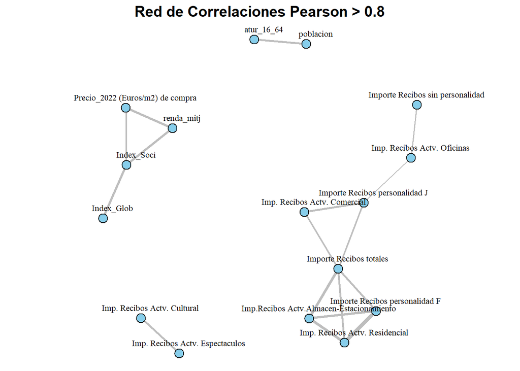

```r
library(igraph)

# Establecer la semilla para reproducibilidad
set.seed(130)

# Crear un grafo
graph_data <- graph_from_data_frame(strong_correlations, directed = FALSE)

# Ajustar atributos del nodo
V(graph_data)$color <- "skyblue"
V(graph_data)$size <- 6
V(graph_data)$frame.color <- "black"

# Queremos que las líneas varíen entre 1 y 5 en grosor
cor_min <- 0.8
cor_max <- 1.0
width_min <- 1
width_max <- 5
E(graph_data)$width <- (abs(E(graph_data)$Correlation) - cor_min) / (cor_max - cor_min) *
                       (width_max - width_min) + width_min

# Elegir un layout que ofrezca más espacio y optimizar para evitar superposición
layout <- layout_with_fr(graph_data)

# Dibujar el gráfico
par(mar = c(0, 0, 1.5, 0)) # Ajustar los márgenes si es necesario
plot(graph_data, layout = layout, vertex.label.color = "black", vertex.label.cex = 0.7,
     vertex.label.dist = 1.2, # Aumentar la distancia de las etiquetas de los nodos
     edge.label = NA, # Ocultar las etiquetas de las aristas para despejar el gráfico
     edge.color = "gray",
     main = "Red de Correlaciones Pearson > 0.8")
```

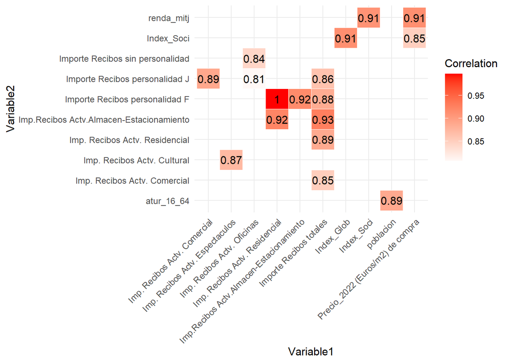

```r
library(ggplot2)

# Crear un gráfico de etiquetas
ggplot(strong_correlations, aes(x = Variable1, y = Variable2, label = round(Correlation, 2))) +
  geom_tile(aes(fill = Correlation), color = "white") +
  geom_text() +
  scale_fill_gradient2(low = "blue", high = "red", mid = "white", midpoint = 0.8) +
  theme_minimal() +
  theme(axis.text.x = element_text(angle = 45, hjust = 1))
```

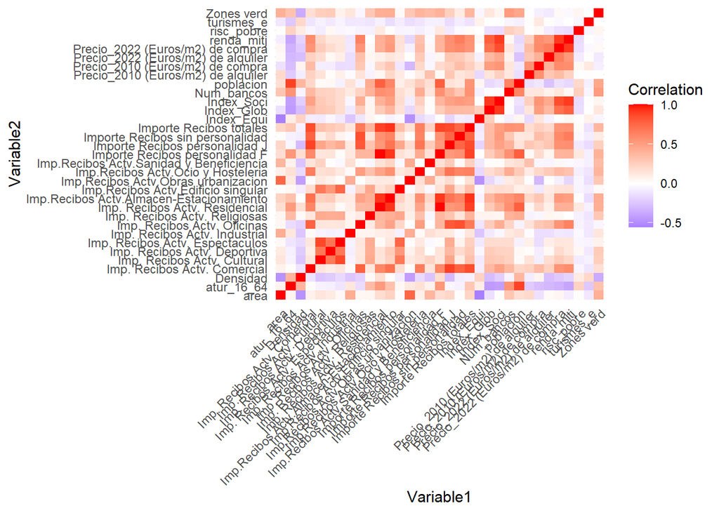

```r
library(ggplot2)
# Convertir cor_pearson a formato largo
cor_pearson_long <- cor_pearson %>%
                    as.data.frame() %>%
                    rownames_to_column(var = "Variable1") %>%
                    gather(key = "Variable2", value = "Correlation", -Variable1)

# Visualizar con ggplot2
ggplot(cor_pearson_long, aes(x = Variable1, y = Variable2, fill = Correlation)) +
    geom_tile() +
    scale_fill_gradient2(low = "blue", high = "red", mid = "white", midpoint = 0) +
    theme_minimal() +
    theme(axis.text.x = element_text(angle = 45, hjust = 1))
```

```r
# Suponiendo que tu dataframe se llama df
write.table(df, file = "barrios.txt", sep = "\t")
```

# Estudio de la vulnerabilidad

## Mapa de barrios vulnerables

```r
#primero creamos un mapa con los barrios y distrito
library(sf)
library(ggplot2)

# Lee el archivo GeoJSON
datos_geojson <- st_read("./data/barris-barrios.geojson")
#datos_geojson$nombre[datos_geojson$nombre %in% df$Barrio]
#df$Barrio[!df$Barrio %in% datos_geojson$nombre]
```

```r
library(leaflet)
# Añado la columna Indice_Vuln al dataframe desde el cual hago el mapa
vuln2 <- vuln[c('Barrio','Indice_Vuln')]
colnames(vuln2) <- c('nombre','Indice_Vuln')
datos_geojson <- merge(x = datos_geojson, y = vuln2)

# Creo los popup del mapa
popups <- paste0("<b>", datos_geojson$nombre, "</b>", "<hr>", datos_geojson$Indice_Vuln)

# Escojo una paleta de colores
pal <- colorFactor(c('red','gray','blue','green'), levels = levels(datos_geojson$Indice_Vuln))

# Creo el mapa
leaflet(data = datos_geojson) %>%
  addTiles() %>%
  addPolygons(fillColor = pal(datos_geojson$Indice_Vuln),
              weight = 1,
              opacity = 1,
              highlightOptions = highlightOptions(color = "white",
                                                  weight = 2,
                                                  bringToFront = TRUE),
              color = 'black',
              fillOpacity = 0.8,
              popup = popups) %>%
  addLegend(data = datos_geojson,
            position = 'bottomright',
            pal = pal, values = ~Indice_Vuln,
            title = 'Leyenda',
            opacity = 1)
```

[interactive chart not shown]

## Representación de los datos

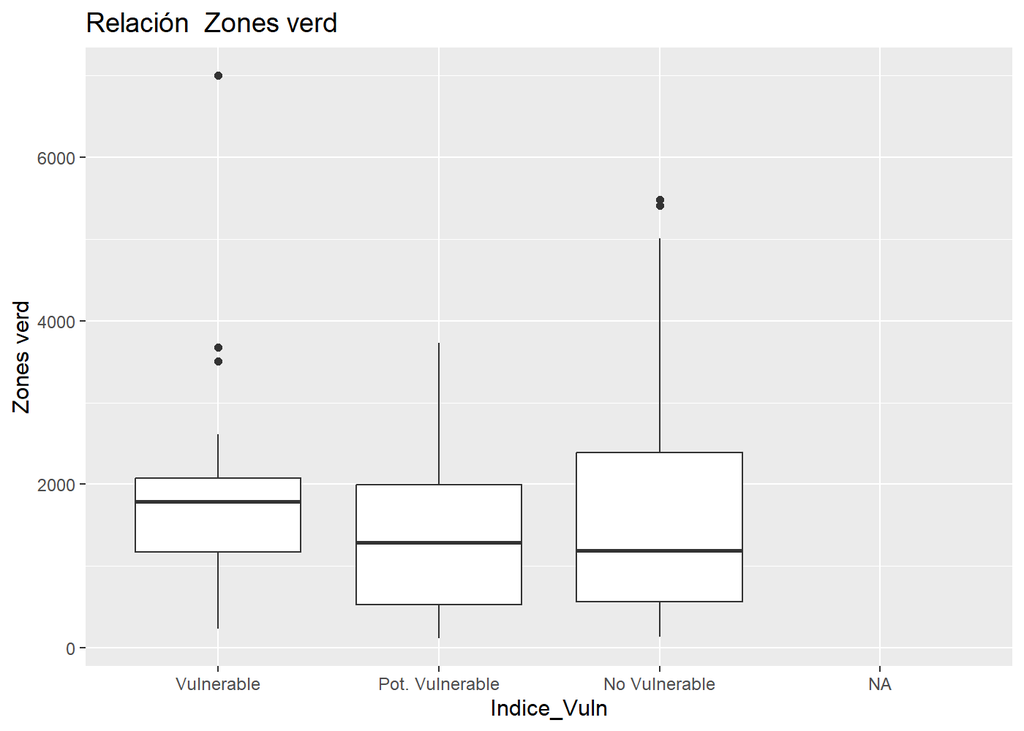

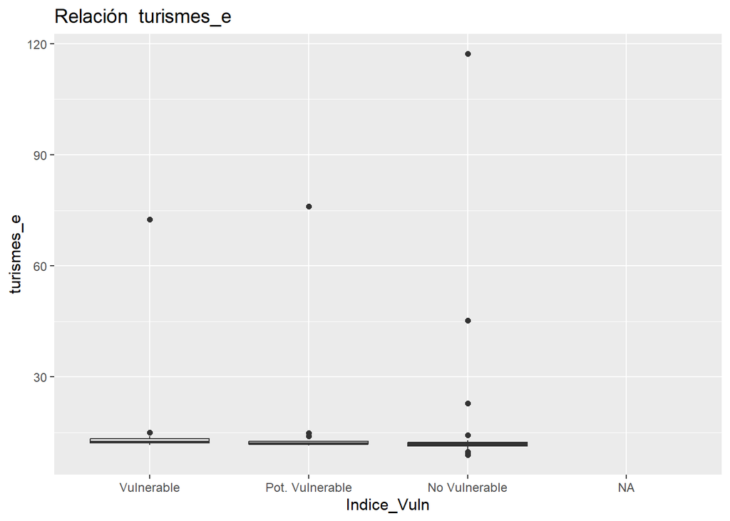

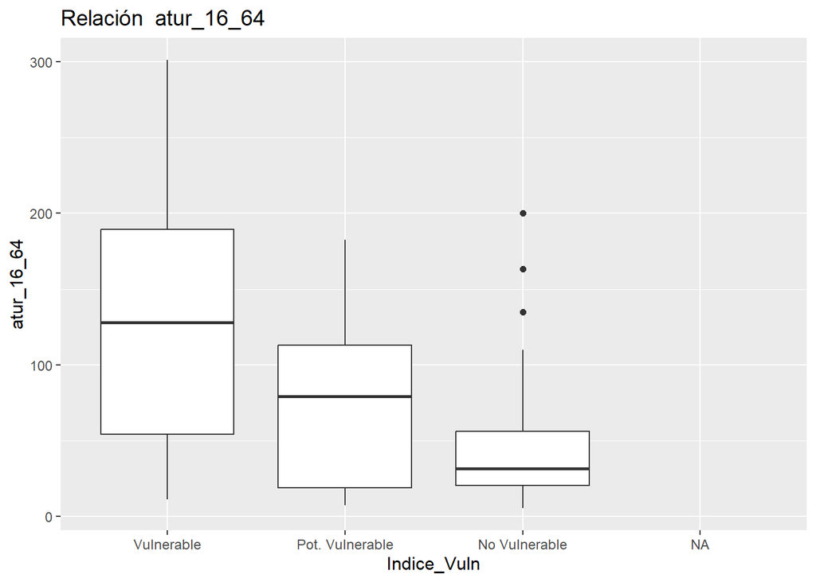

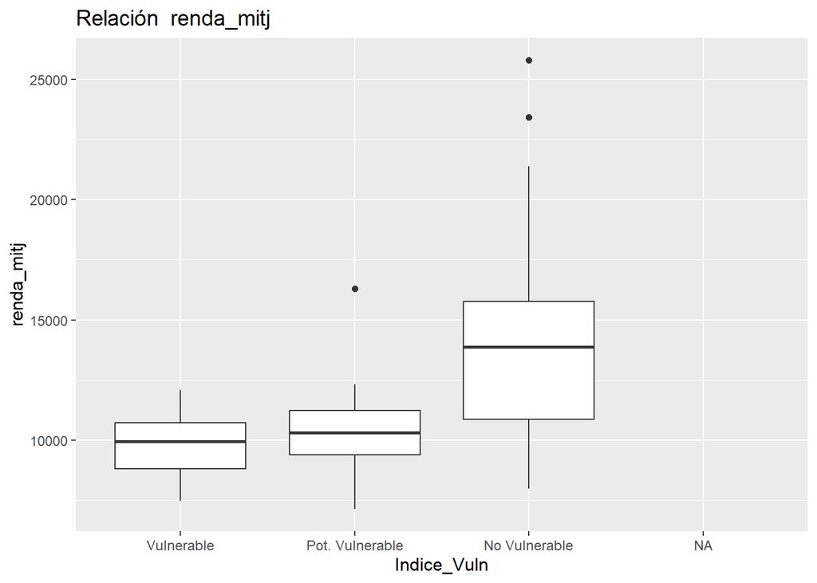

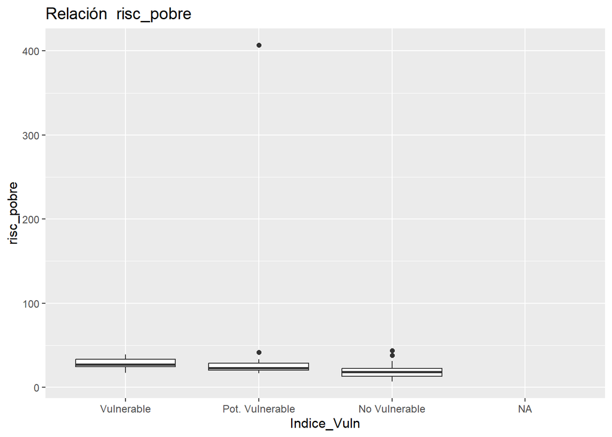

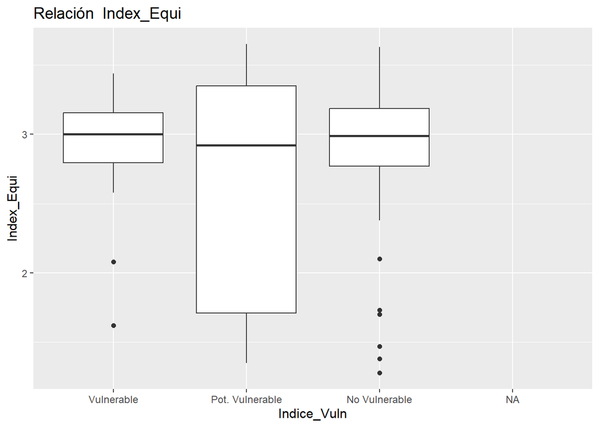

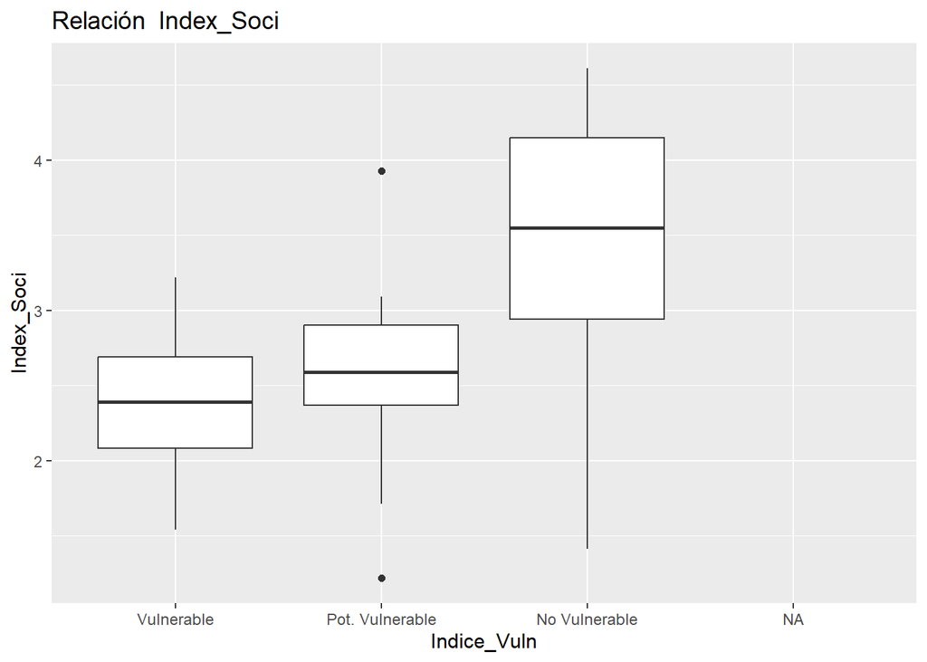

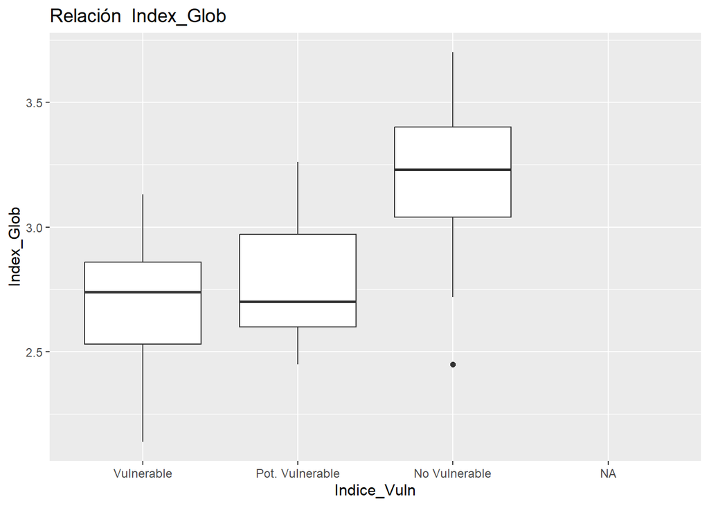

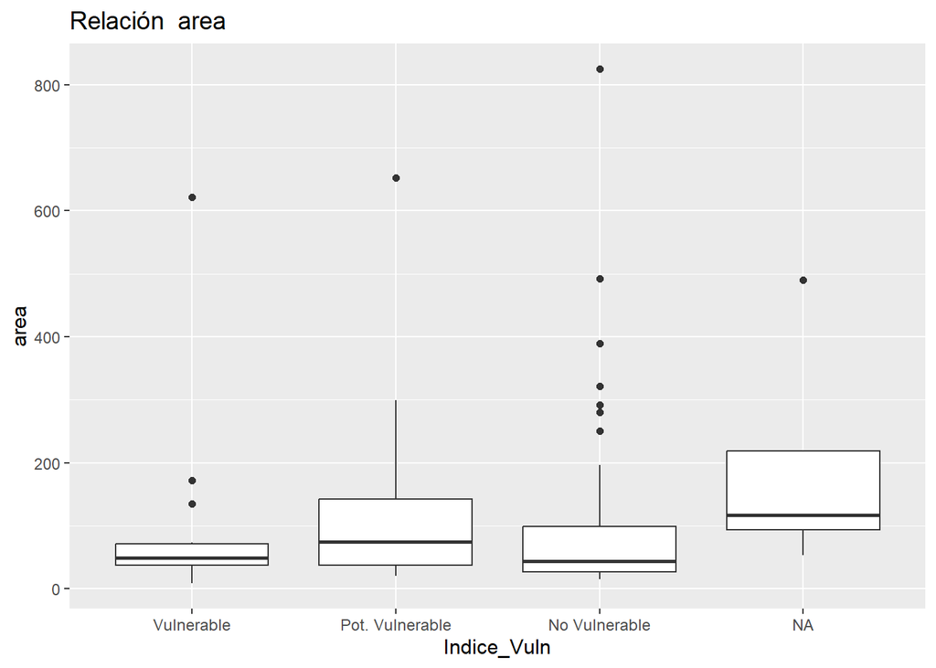

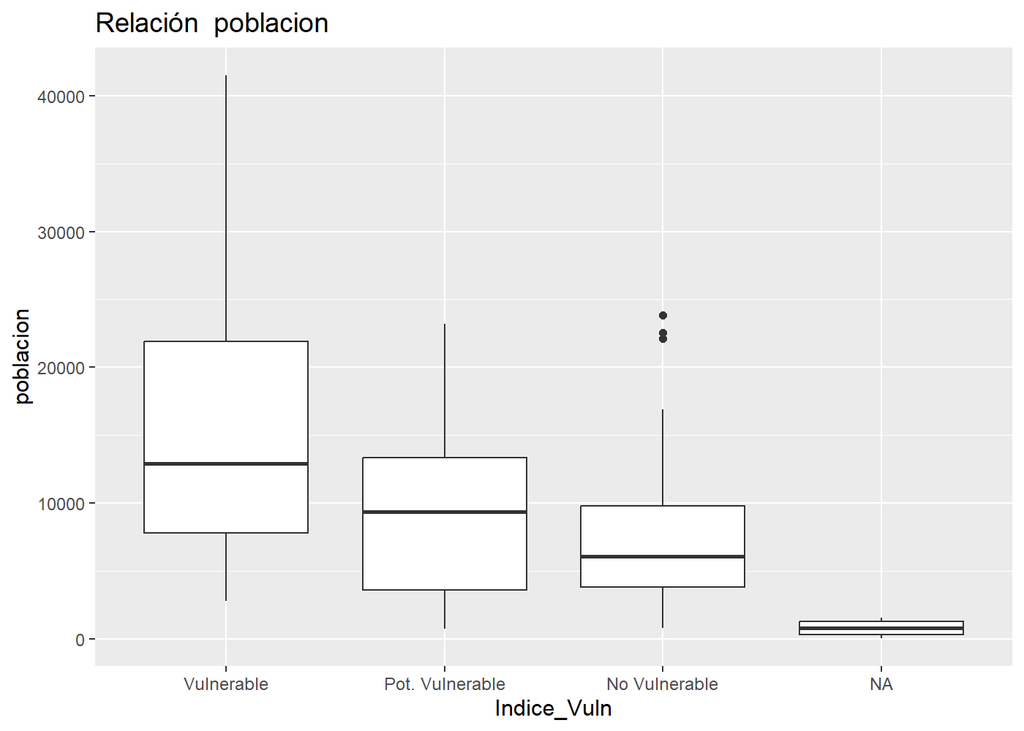

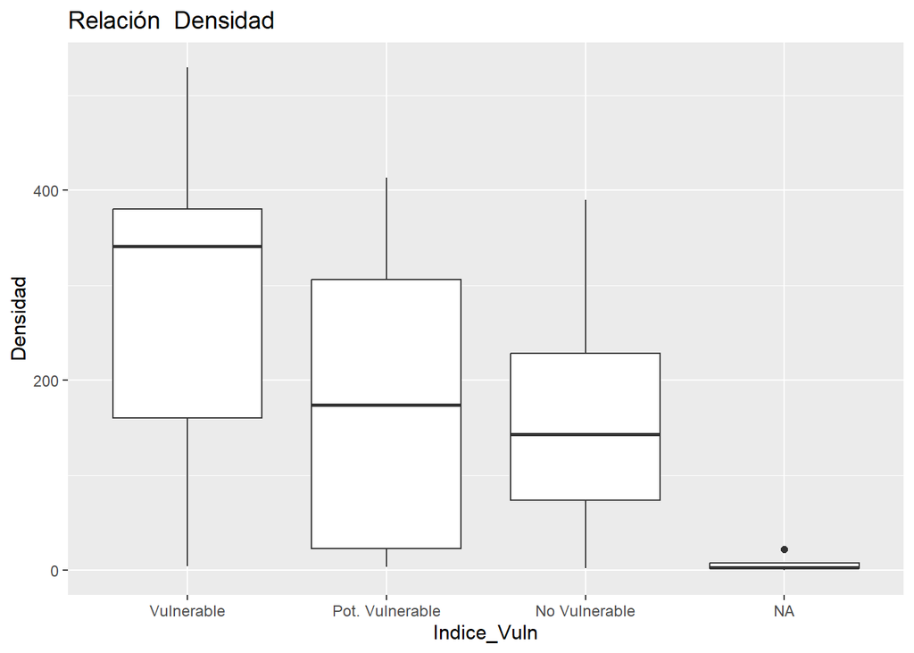

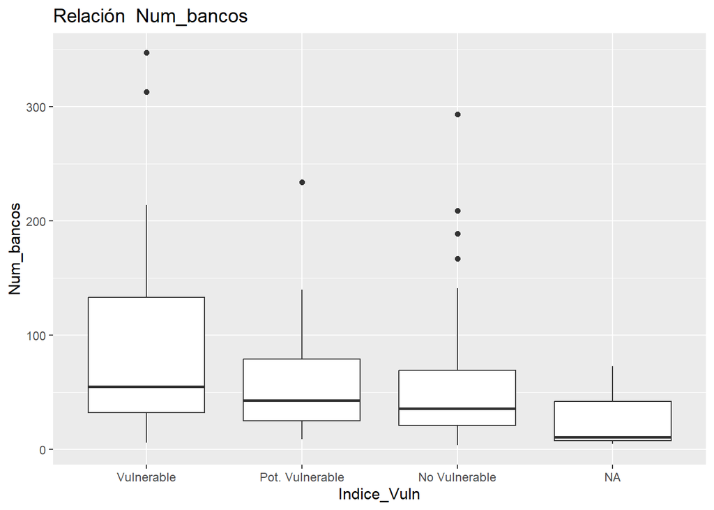

[21 more figures not shown]

```r
# me quedo con las columnas numéricas + Indice_Vuln de df
columnas_numericas <- df %>%
  select_if(is.numeric) %>%
  colnames()
columnas_numéricas <- c(columnas_numericas, 'Indice_Vuln')
columnas_numéricas <- df[columnas_numéricas]

# Muestro un box-plot para cada variable numérica diferenciando 4 distribuciones en función de la vulnerabilidad
for (i in columnas_numericas) {
  p<-ggplot(columnas_numéricas, aes(x = Indice_Vuln, y =.data[[i]])) +
    geom_boxplot() +
    ggtitle(paste("Relación ", i))
  print(p)
}
```

## Detección de anomalías

### Detección de valores perdidos

Antes de tratar con nuestros datos, vamos a analizar la situación de nuestro dataset. Primero, vamos a analizar los valores perdidos.

```r
sum(is.na(df))
```

```
[1] 140
```

Podemos ver que la cantidad de valores perdidos en nuestro conjunto no es precisamente pequeña, y principalmente se debe al hecho de que no todos los conjuntos de datos que hemos fusionado contenían información de todos los barrios, por lo que a la hora de unirlos todos se han generado NAs en las observaciones donde no existían datos. Vamos a ver el estado de nuestras variables:

```r
summary(df)
```

```
         Barrio               Distrito           Indice_Vuln   Zones verd       turismes_e
 AIORA      : 1   POBLATS DEL NORD: 8   Vulnerable     :19   Min.   : 120.0   Min.   :  9.04
 ALBORS     : 1   POBLATS DEL SUD : 8   Pot. Vulnerable:17   1st Qu.: 697.5   1st Qu.: 11.64
 ARRANCAPINS: 1   QUATRE CARRERES : 7   No Vulnerable  :47   Median :1312.0   Median : 12.09
 BENICALAP  : 1   CIUTAT VELLA    : 6   NA's           : 5   Mean   :1678.8   Mean   : 15.34
 BENIFARAIG : 1   CAMINS AL GRAU  : 5                        3rd Qu.:2101.0   3rd Qu.: 12.55
 BENIFERRI  : 1   POBLATS MARITIMS: 5                        Max.   :6999.0   Max.   :117.21
 (Other)    :82   (Other)         :49                        NA's   :5        NA's   :5
   atur_16_64       renda_mitj      risc_pobre       Index_Equi      Index_Soci      Index_Glob
 Min.   :  5.64   Min.   : 7145   Min.   :  7.10   Min.   :1.280   Min.   :1.220   Min.   :2.140
 1st Qu.: 21.57   1st Qu.: 9933   1st Qu.: 17.18   1st Qu.:2.745   1st Qu.:2.560   1st Qu.:2.740
 Median : 53.78   Median :11227   Median : 20.97   Median :2.970   Median :2.950   Median :3.040
 Mean   : 71.57   Mean   :12390   Mean   : 26.47   Mean   :2.828   Mean   :3.077   Mean   :3.011
 3rd Qu.:109.52   3rd Qu.:14484   3rd Qu.: 25.99   3rd Qu.:3.180   3rd Qu.:3.615   3rd Qu.:3.300
 Max.   :300.97   Max.   :25795   Max.   :406.70   Max.   :3.650   Max.   :4.610   Max.   :3.700
 NA's   :5        NA's   :5       NA's   :5        NA's   :5       NA's   :5       NA's   :5
      area          poblacion        Densidad          Num_bancos
 Min.   :  9.40   Min.   :   58   Min.   :  0.5426   Min.   :  4.00
 1st Qu.: 32.65   1st Qu.: 3792   1st Qu.: 73.7938   1st Qu.: 23.00
 Median : 49.70   Median : 7084   Median :174.2773   Median : 39.00
 Mean   :111.22   Mean   : 9197   Mean   :184.1990   Mean   : 66.05
 3rd Qu.:113.50   3rd Qu.:12005   3rd Qu.:296.7284   3rd Qu.: 78.00
 Max.   :824.80   Max.   :41483   Max.   :529.1489   Max.   :347.00
 NA's   :1        NA's   :1       NA's   :1          NA's   :3
 Precio_2022 (Euros/m2) de compra Precio_2010 (Euros/m2) de compra
 Min.   :1103                     Min.   :1162
 1st Qu.:1619                     1st Qu.:1408
 Median :1948                     Median :1782
 Mean   :2109                     Mean   :1748
 3rd Qu.:2558                     3rd Qu.:2098
 Max.   :4029                     Max.   :2455
 NA's   :18                       NA's   :18
 Precio_2022 (Euros/m2) de alquiler Precio_2010 (Euros/m2) de alquiler
 Min.   : 3.00                      Min.   :5.600
 1st Qu.: 8.40                      1st Qu.:6.200
 Median : 9.20                      Median :6.700
 Mean   : 9.24                      Mean   :6.634
 3rd Qu.:10.00                      3rd Qu.:6.900
 Max.   :13.20                      Max.   :9.200
 NA's   :18                         NA's   :18
```

[output cut: 33 more lines]

```
 Min.   :     0.0                   Min.   :      0             Min.   :    0.0
 1st Qu.:   473.2                   1st Qu.:   7158             1st Qu.:    0.0
 Median :  6140.9                   Median :  32072             Median :    0.0
 Mean   : 63647.1                   Mean   : 158026             Mean   :  997.6
 3rd Qu.: 37142.9                   3rd Qu.: 109142             3rd Qu.:  625.3
 Max.   :823072.6                   Max.   :2961486             Max.   :11489.9
 NA's   :1                          NA's   :1                   NA's   :1
 Imp. Recibos Actv. Residencial Imp.Recibos Actv.Sanidad y Beneficiencia Importe Recibos totales
 Min.   :  14122                Min.   :      0                          Min.   :   14994
 1st Qu.: 680254                1st Qu.:    310                          1st Qu.:  946959
 Median :1312627                Median :   6381                          Median : 1841102
 Mean   :1627169                Mean   :  53079                          Mean   : 2646641
 3rd Qu.:2337007                3rd Qu.:  26475                          3rd Qu.: 3348840
 Max.   :5857109                Max.   :1621880                          Max.   :12119614
 NA's   :1                      NA's   :1                                NA's   :1
```

Una cosa que salta a la vista de las variables del dataset IBI es que cuentan con un único NA, por lo que podemos suponer que se debe a la misma observación, y efectivamente, ésta es la del barrio “RAFALELL-VISTABELLA”, que no cuenta con ninguna información numérica en nuestro dataset. Por ello, lo mejor que podemos hacer es eliminar la observación.

```r
df[df$Barrio=="RAFALELL-VISTABELLA",]
```

```
# A tibble: 1 × 36
  Barrio    Distrito Indice_Vuln `Zones verd` turismes_e atur_16_64 renda_mitj risc_pobre Index_Equi
  <fct>     <fct>    <fct>              <dbl>      <dbl>      <dbl>      <dbl>      <dbl>      <dbl>
1 RAFALELL… POBLATS… <NA>                  NA         NA         NA         NA         NA         NA
# ℹ 27 more variables: Index_Soci <dbl>, Index_Glob <dbl>, area <dbl>, poblacion <dbl>,
#   Densidad <dbl>, Num_bancos <int>, `Precio_2022 (Euros/m2) de compra` <dbl>,
#   `Precio_2010 (Euros/m2) de compra` <dbl>, `Precio_2022 (Euros/m2) de alquiler` <dbl>,
#   `Precio_2010 (Euros/m2) de alquiler` <dbl>, `Importe Recibos personalidad F` <dbl>,
#   `Importe Recibos personalidad J` <dbl>, `Importe Recibos sin personalidad` <dbl>,
#   `Imp.Recibos Actv.Almacen-Estacionamiento` <dbl>, `Imp. Recibos Actv. Comercial` <dbl>,
#   `Imp. Recibos Actv. Cultural` <dbl>, `Imp. Recibos Actv. Deportiva` <dbl>, …
```

```r
df%<>%drop_na("Importe Recibos personalidad F")
```

Otra que resalta de las variables provenientes del dataset IBI es que cuentan con un mínimo de 0, mientras que la media de los valores ronda valores muy altos. Esto se puede deber a que hay ciertas actividades que están presentes en un pequeño número de barrios, como los espectáculos o la actividad religiosa. Dado que estos datos tienen sentido, vamos a mantenerlos, ya que pasarlos a NA nos daría una media de estas actividades totalmente irreal. En cambio, en el resto de variables, como precios de alquiler y compra, y zonas verdes, si sería interesante cambiar estos NA por la mediana de los barrios de su misma vulnerabilidad, ya que estos NA si se pueden deber a una ausencia de medición.

```r
reg<-lm(`Precio_2022 (Euros/m2) de compra`~renda_mitj,df)

df%<>%mutate(`Precio_2022 (Euros/m2) de compra`=ifelse(is.na(`Precio_2022 (Euros/m2) de compra`)&!is.na(renda_mitj),reg$coefficients[1]+renda_mitj*reg$coefficients[2],`Precio_2022 (Euros/m2) de compra`))

df %<>%
  group_by(`Indice_Vuln`) %>%
  mutate(`Precio_2022 (Euros/m2) de compra`=ifelse(is.na(`Precio_2022 (Euros/m2) de compra`),median(`Precio_2022 (Euros/m2) de compra`,na.rm = TRUE),`Precio_2022 (Euros/m2) de compra`))%>%
  ungroup()
```

```r
df %<>%
  group_by(`Indice_Vuln`) %>%
  mutate(`Precio_2010 (Euros/m2) de compra`=ifelse(is.na(`Precio_2010 (Euros/m2) de compra`),median(`Precio_2010 (Euros/m2) de compra`,na.rm = TRUE),`Precio_2010 (Euros/m2) de compra`))%>%
  ungroup()
```

```r
df %<>%
  group_by(`Indice_Vuln`) %>%
  mutate(`Precio_2022 (Euros/m2) de alquiler`=ifelse(is.na(`Precio_2022 (Euros/m2) de alquiler`),median(`Precio_2022 (Euros/m2) de alquiler`,na.rm = TRUE),`Precio_2022 (Euros/m2) de alquiler`))%>%
  ungroup()
```

```r
df %<>%
  group_by(`Indice_Vuln`) %>%
  mutate(`Precio_2010 (Euros/m2) de alquiler`=ifelse(is.na(`Precio_2010 (Euros/m2) de alquiler`),median(`Precio_2010 (Euros/m2) de alquiler`,na.rm = TRUE),`Precio_2010 (Euros/m2) de alquiler`))%>%
  ungroup()
```

```r
summary(df)
```

```
         Barrio               Distrito           Indice_Vuln   Zones verd       turismes_e
 AIORA      : 1   POBLATS DEL SUD : 8   Vulnerable     :19   Min.   : 120.0   Min.   :  9.04
 ALBORS     : 1   POBLATS DEL NORD: 7   Pot. Vulnerable:17   1st Qu.: 697.5   1st Qu.: 11.64
 ARRANCAPINS: 1   QUATRE CARRERES : 7   No Vulnerable  :47   Median :1312.0   Median : 12.09
 BENICALAP  : 1   CIUTAT VELLA    : 6   NA's           : 4   Mean   :1678.8   Mean   : 15.34
 BENIFARAIG : 1   CAMINS AL GRAU  : 5                        3rd Qu.:2101.0   3rd Qu.: 12.55
 BENIFERRI  : 1   POBLATS MARITIMS: 5                        Max.   :6999.0   Max.   :117.21
 (Other)    :81   (Other)         :49                        NA's   :4        NA's   :4
   atur_16_64       renda_mitj      risc_pobre       Index_Equi      Index_Soci      Index_Glob
 Min.   :  5.64   Min.   : 7145   Min.   :  7.10   Min.   :1.280   Min.   :1.220   Min.   :2.140
 1st Qu.: 21.57   1st Qu.: 9933   1st Qu.: 17.18   1st Qu.:2.745   1st Qu.:2.560   1st Qu.:2.740
 Median : 53.78   Median :11227   Median : 20.97   Median :2.970   Median :2.950   Median :3.040
 Mean   : 71.57   Mean   :12390   Mean   : 26.47   Mean   :2.828   Mean   :3.077   Mean   :3.011
 3rd Qu.:109.52   3rd Qu.:14484   3rd Qu.: 25.99   3rd Qu.:3.180   3rd Qu.:3.615   3rd Qu.:3.300
 Max.   :300.97   Max.   :25795   Max.   :406.70   Max.   :3.650   Max.   :4.610   Max.   :3.700
 NA's   :4        NA's   :4       NA's   :4        NA's   :4       NA's   :4       NA's   :4
      area          poblacion        Densidad          Num_bancos
 Min.   :  9.40   Min.   :   58   Min.   :  0.5426   Min.   :  4.00
 1st Qu.: 32.65   1st Qu.: 3792   1st Qu.: 73.7938   1st Qu.: 23.00
 Median : 49.70   Median : 7084   Median :174.2773   Median : 39.00
 Mean   :111.22   Mean   : 9197   Mean   :184.1990   Mean   : 66.05
 3rd Qu.:113.50   3rd Qu.:12005   3rd Qu.:296.7284   3rd Qu.: 78.00
 Max.   :824.80   Max.   :41483   Max.   :529.1489   Max.   :347.00
                                                     NA's   :2
 Precio_2022 (Euros/m2) de compra Precio_2010 (Euros/m2) de compra
 Min.   :1103                     Min.   :1162
 1st Qu.:1622                     1st Qu.:1408
 Median :1893                     Median :1771
 Mean   :2073                     Mean   :1737
 3rd Qu.:2408                     3rd Qu.:1976
 Max.   :4029                     Max.   :2455
 NA's   :4                        NA's   :4
 Precio_2022 (Euros/m2) de alquiler Precio_2010 (Euros/m2) de alquiler
 Min.   : 3.00                      Min.   :5.600
 1st Qu.: 8.40                      1st Qu.:6.000
 Median : 9.20                      Median :6.700
 Mean   : 9.19                      Mean   :6.592
 3rd Qu.: 9.80                      3rd Qu.:6.850
 Max.   :13.20                      Max.   :9.200
 NA's   :4                          NA's   :4
```

[output cut: 32 more lines]

```
 Imp.Recibos Actv.Ocio y Hosteleria Imp. Recibos Actv. Oficinas Imp. Recibos Actv. Religiosas
 Min.   :     0.0                   Min.   :      0             Min.   :    0.0
 1st Qu.:   473.2                   1st Qu.:   7158             1st Qu.:    0.0
 Median :  6140.9                   Median :  32072             Median :    0.0
 Mean   : 63647.1                   Mean   : 158026             Mean   :  997.6
 3rd Qu.: 37142.9                   3rd Qu.: 109142             3rd Qu.:  625.3
 Max.   :823072.6                   Max.   :2961486             Max.   :11489.9

 Imp. Recibos Actv. Residencial Imp.Recibos Actv.Sanidad y Beneficiencia Importe Recibos totales
 Min.   :  14122                Min.   :      0                          Min.   :   14994
 1st Qu.: 680254                1st Qu.:    310                          1st Qu.:  946959
 Median :1312627                Median :   6381                          Median : 1841102
 Mean   :1627169                Mean   :  53079                          Mean   : 2646641
 3rd Qu.:2337007                3rd Qu.:  26475                          3rd Qu.: 3348840
 Max.   :5857109                Max.   :1621880                          Max.   :12119614
```

Tras esto hemos logrado pasar de tener un número muy elevado de NAs a tener solo 4 en ciertas varibles. Estos NAs están en los barrios que carecen de índice de vulverabilidad, por lo que tendremos que esperar a ponerles una etiqueta a estos barrios para librarnos de los NAs de forma adecuada.

### Detección de outliers

Vamos a tratar los outliers de nuestro conjunto antes de empezar a trabajar.

Para la detección de outliers vamos a usar los métodos 3-sigma y boxplot, con las funciones definidas en la práctica 5.

```r
reglasigma<-function(x){
  x<-x[!is.na(x)& is.numeric(x)]
  out <- logical(length(x))

  for(i in 1:length(x)){
    if(abs(x[i]-mean(x))>3*sd(x)){
      out[i]<-TRUE
    }
  }
  if (all(!out)){
    return(NA)
  } else {
    return(out)
  }
}

reglaboxplot<-function(x){
  x<-x[!is.na(x)& is.numeric(x)]
  out <- logical(length(x))

  for(i in 1:length(x)){
    if(x[i]>quantile(x,0.75)+1.5*IQR(x)){
      out[i]<-TRUE
    } else if (x[i]<quantile(x,0.25)-1.5*IQR(x)){
      out[i]<-TRUE
    }
  }
  if (all(!out)){
    return(NA)
  } else {
    return(out)
  }
}
```

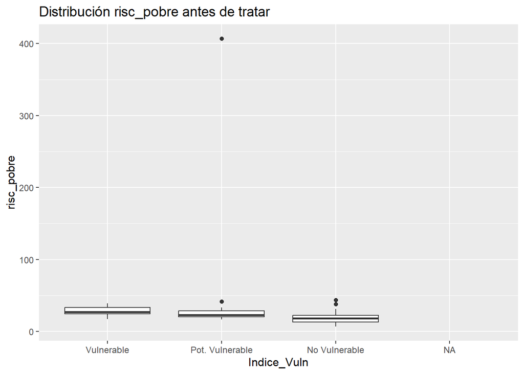

```r
# Corrección de outliers gráfica
ggplot(df, aes(x = Indice_Vuln, y = risc_pobre)) + geom_boxplot() + ggtitle('Distribución risc_pobre antes de tratar')
```

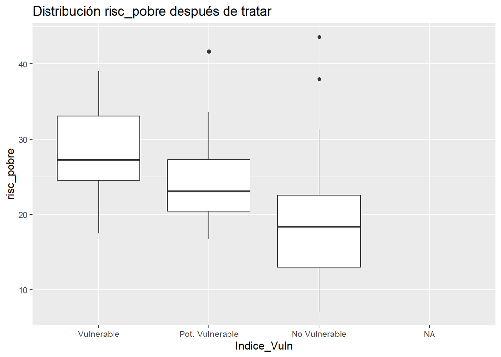

```r
risc_pobre_filtrada <- df %>%
  filter(Indice_Vuln == 'Vulnerable') %>%
  filter(risc_pobre < 100) %>%
  select(risc_pobre)
df$risc_pobre[df['Barrio'] == 'BENIMACLET'] <- median(risc_pobre_filtrada[[1]])

ggplot(df, aes(x = Indice_Vuln, y = risc_pobre)) + geom_boxplot() + ggtitle('Distribución risc_pobre después de tratar')
```

Para el resto de variables, vamos a aplicar las funciones vistas en busca de posibles outliers.

```r
outliers <- df %>%
  summarise(across(where(is.numeric), list(Sigma = ~sum(reglasigma(.)), Boxplot = ~sum(reglaboxplot(.))),.names = "{col};{fn}"))

outliers%<>%
  pivot_longer(cols=everything(), names_to = "Var",values_to = "Valor")%>%
  separate(Var,into=c("Variable", "Regla"),sep=";")%>%
  spread(key=Regla,value=Valor)

outliers
```

```
# A tibble: 33 × 3
   Variable                        Boxplot Sigma
   <chr>                             <int> <int>
 1 area                                 11     3
 2 atur_16_64                            2     1
 3 Densidad                             NA    NA
 4 Imp. Recibos Actv. Comercial          9     3
 5 Imp. Recibos Actv. Cultural          10     1
 6 Imp. Recibos Actv. Deportiva         13     3
 7 Imp. Recibos Actv. Espectaculos      16     1
 8 Imp. Recibos Actv. Industrial         6     2
 9 Imp. Recibos Actv. Oficinas          11     2
10 Imp. Recibos Actv. Religiosas        10     5
# ℹ 23 more rows
```

Viendo que la función boxplot detecta un número excesivo de outliers contando las pocas observaciones que tenemos, vamos a hacer caso a la regla sigma, y en caso de que haga falta modificar los outliers, solamente trataremos los que esta detecta, pasandolos a la mediana al igual que el ejemplo anterior, o usando alguna otra columna que esté muy correlacionada.

Un ejemplo de outlier puede verse en la variable que muestra la actividad cultural del barrio, viendo como la ciudad de las artes y las ciencias tiene un valor muchísimo más alto que el resto:

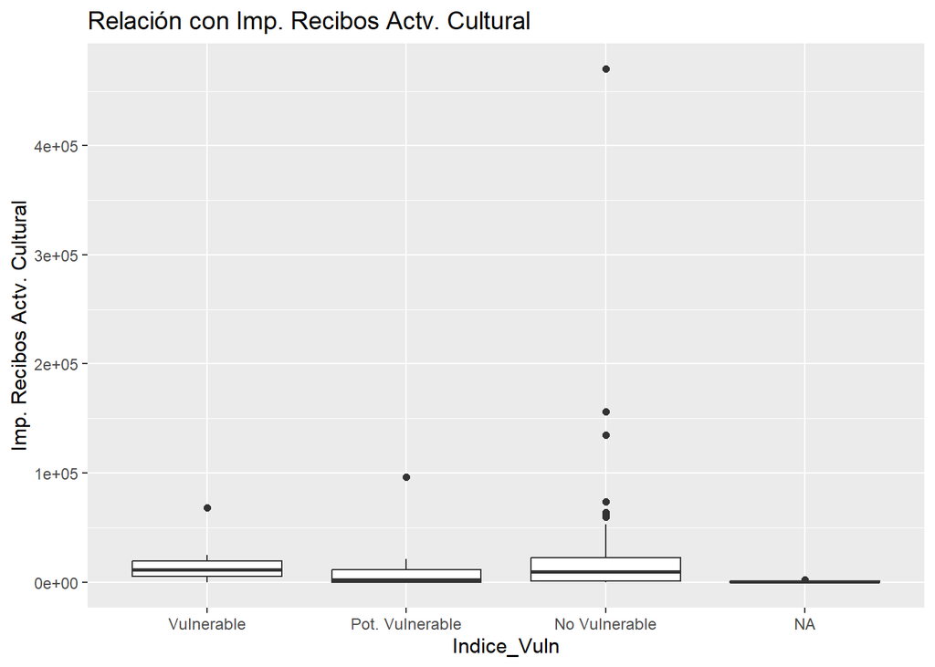

```r
p<-ggplot(df[c("Imp. Recibos Actv. Cultural","Indice_Vuln")], aes(x = Indice_Vuln, y =.data[["Imp. Recibos Actv. Cultural"]])) +
    geom_boxplot() +
    ggtitle(paste("Relación con Imp. Recibos Actv. Cultural"))
  print(p)
```

```r
  print(df$`Imp. Recibos Actv. Cultural`[df$Barrio=="CIUTAT DE LES ARTS I DE LES CIENCIES"])
```

```
[1] 470265.7
```

Vemos como dentro de los barrios no vulnerables el de la ciudad de las artes y las ciencias tiene una actividad muchísimo mayor, con un valor de 470265.7. Aun así, debido a que este dato no se debe a un error a la hora de introducir el valor en el conjunto, pero se debe a que el barrio tiene una actividad cultural mayor debido a su situación, mantendremos estos outliers en nuestro dataset.